# Traffic Flow with PDEs

## ICFP M1 Numercial Physics Project 2017-2018

### Rob Hesselink (rob.hesselink@ens.fr) Moshir Harsh (moshir.harsh@ens.fr)

[figure not shown]

Old U.S. 395 Highway Sand Diego from http://www.garbell.com/US395-old/395.htm

[figure not shown]

From autoevolution

[figure not shown]

From Blogex

[figure not shown]

From Berklee Science Review

## In come the Physicists

### Mathematically Model Traffic Flows and Traffic Jams

- Do what we know best: Model with PDEs
- This approach has resulted in numerous publications
- PDEs better to use over Difference Equations:
  - In the limit of large number, continuous descriptions work well because relative fluctuations are small
  - Analytical Results sometimes available
  - More robust to chaos
  - Successfully used bye Ecologists for years
- Exploring non-linearities in nature

[figure not shown]

## Mathematical Models and Lighthill–Whitham–Richards (LWR) Equation

### The basic idea

- Analogy with fluid flow models
- Cars modelled with a **density field $\rho(\vec{x})$** and with a **velocity field $u(\vec{x})$**
- Objective is to determine $\rho(t,\vec{x})$ and $u(t,\vec{x})$ given appropriate boundary conditions
- PDE which relates the time and space evolution of density and velocity under the appropriate physical law governing the traffic flow

### Congestion

- Velocity u as a function of the density $\rho$
- Physically at low densities, the cars will go at high velocities with $v_0$ being the maximum velocity
- if the density of cars get high, the velocity of cars will decrease linearly due to congestion, becoming 0 at $\rho = \rho_0$
- \begin{equation} u = v_0\left(1-\frac{\rho}{\rho_0}\right) \end{equation}
- Here we study 1-dimensional traffic flow

### Continuity Equation

- We consider a **circular road with no input nor output flux of cars**
- The **number of cars should be conserved in time**
- Use the **continuity equation for an incompressible fluid**
- \begin{equation} \frac{\partial \rho}{\partial t} + \frac{\partial (\rho u)}{\partial x} = 0 \end{equation}

### The Model Equation

Combining the Previous Equations we get:

\begin{equation} \frac{\partial \rho}{\partial t} + \frac{\partial}{\partial x}\left[ v_0 \left(1-\frac{\rho}{\rho_0}\right)\rho \right] = 0 \end{equation}

where **$v_0$ and $\rho_0$ are the parameters which are set to one** without loss of generality. So the equation becomes:

\begin{equation} \frac{\partial \rho}{\partial t} + \frac{\partial}{\partial x}\left[ \left(1-\rho\right)\rho \right] = 0 \end{equation}

This equation can also be written as:

\begin{equation} \frac{\partial \rho}{\partial t} + \left(1-2\rho\right)\frac{\partial \rho}{\partial x} = 0 \end{equation}

This is the simplest **Lighthill–Whitham–Richards LWR model**. This equation is also known as the **inviscid Burgers' equation** which form huge discontinuities commonly referred to as **shock**. The LWR equation was developed in 1955 and 1956 by Lighthill and Whitham, and independently also by Richards.

## Burgers' Equation and Shocks

### Advection Equation

- **Hyperbolic partial differential equations**
- Notorious for numerical schemes to handle due to shocks.

### Shocks

- The propagation velocity decreases with density,
- Highly dense and slowly moving regions, and rare and highly mobile regions which propagate as a shock wave.
- Steep gradient or a discontinuity in $\rho$, which propagates at a velocity, called a shock wave velocity.
- The numerical treatment of shocks is difficult due to the increasing discontinuity and methods fail as the gradient grows.
- Traditional schemes like Finite Elements and Finite Volumes don't work well
- Replaced by the Gudonov method to obtain correct solutions up until shock formation
- Once the shock has formed, many numerical schemes no longer perform well

[figure not shown]

Image from http://laurent.nack.pagesperso-orange.fr/burgers/burger.htm

### Numerically Solving the LWR Equation

**1D space on an x-grid** that goes from 0 to 1.

**periodic boundary conditions** which amounts to solving traffic flow on a **circular road** with neither exits nor entrances:

\begin{equation} \rho(x+1) = \rho(x) \end{equation}

Subjected to the initial conditions:

\begin{equation} \rho(t=0,x) = 0.2 + 0.1sin(2\pi x) \end{equation}

The density $\rho>0$ $\forall$ x and stays that way $\forall$ t. NOTE: Negative density of cars is unphysical.

The total **integration time, T = 1** with the **number of grid points = N**

The time increment **$\Delta t=\frac{1}{N}=\frac{1}{100} $** and spatial increment, **$\Delta x=\frac{1}{N}=\frac{1}{100}$**.

Since we consider a 1D circular road with no output or input flux of cars, the **total number of cars on the road = M, should stay constant in time**:

\begin{equation} M(t) = \int_{0}^{1} \rho(t,x)dx = \sum_{i=0}^{1} \rho(t,x_i) \end{equation}

### CFL Condition

The **Courant-Friedrichs-Lewy condition** is a condition for the convergence of numerical methods for partial differential equations.

It states:**the numerical domain of dependence must include the physical domain of dependence**.

The analytical domain of dependence for the WLR equation is $c\Delta t$: the distance a wave can travel during time step $\Delta t$.

The numerical domain of dependence is $\Delta x$, since in all schemes used here, interaction happens with nearest neighbours. This results in the CFL condition of

\begin{equation} (1-2\rho) \frac{\Delta t}{\Delta x} \leq 1. \end{equation}

If the condition is violated, information is lost in the simulation that is contained in the original WLR equation. This loss of information impedes convergence and often destabilizes the scheme.

### Overview

We simulate the solution to this equation using different schemes and compare our results:

We also discuss the following:

1. Dispersive and/or the dissipative nature of these schemes
2. Their **stability**
3. **Modified wavenumber** analysis
4. The **truncation error**
5. The **order of accuracy**
6. **Dependence of the error on the grid size** in time and space

## Finite Difference Methods

### Lax-Friedrichs $\mathcal{O}(\Delta t, \frac{\Delta x^2}{\Delta t})$

\begin{equation} u_x^{t+1} = \frac{u_{x+1}^t + u_{x-1}^t}{2} - (1 - 2u)\frac{\Delta t}{2 \Delta x}(u_{x+1}^t - u_{x-1}^t) \end{equation}

```python
run(LF)
```

[video not shown]

##### Stability (CFL):

\begin{align} \xi &= \frac{e^{ik\Delta x} + e^{-ik\Delta x}}{2} - (1 - 2u)\frac{\Delta t}{2 \Delta x} \left(e^{ik\Delta x} - e^{ik\Delta x}\right) \end{align} Amplification factor: \begin{align} |\xi|^2 &= \cos^2{k\Delta x} + r^2 \sin^2{k\Delta x} \\ &= 1 - (1 - r^2)\sin^2{k\Delta x}, \end{align}

where

\begin{equation} |r| \equiv \left| \frac{\Delta t}{\Delta x}(1 - 2u)\right| \leq 1 \end{equation}

##### Dissipation:

\begin{align} \frac{u_{x+1}^t + u_{x-1}^t}{2} &= u_x^t + \frac{\Delta x^2}{2}\frac{\partial^2 u}{\partial x^2} + \mathcal{O}(x^4), \end{align}

- Provides conditional stability
- Introduces numerical dissipation

### Lax-Wendroff $\mathcal{O}(\Delta t^2, \Delta x^2)$

\begin{align} u_x^{t+1} = u_x^t - (1-2u)\frac{\Delta t}{2 \Delta x}(u_{x+1}^t - u_{x-1}^t) + (1-2u)^2\frac{\Delta t^2}{2 \Delta x^2} (u_{x+1}^t - 2u_x^t + u_{x-1}^t). \end{align}

```python
run(LW)
```

[video not shown]

##### Compensating for dissipation:

- Identify leading order term: \begin{align} \frac{u_x^{t+1} - u_x^t}{\Delta t} &= \frac{\partial u}{\partial t} + \color{blue}{\frac{\Delta t}{2}\frac{\partial^2 u}{\partial t^2}} + \frac{\Delta t^2}{6} \frac{\partial^3 u}{\partial t^3} + \mathcal{O}(\Delta t^3) \text{, and} \\ \frac{u_{x+1}^t - u_{x-1}^t}{2\Delta x} &= \frac{\partial u}{\partial x} + \color{blue}{\frac{\Delta x^2}{6}\frac{\partial^3 u}{\partial x^3}} + \mathcal{O}(\Delta x^4) \end{align}
- Compensate for the $\Delta t$ term: \begin{align} \frac{\Delta t}{2}\frac{\partial^2 u}{\partial t^2} &= -(1-2u)^2\frac{\Delta t}{2}\frac{\partial^2 u}{\partial x^2} \\ &= -(1-2u)^2\frac{\Delta t^2}{2 \Delta x^2} (u_{x+1}^t - 2u_x^t + u_{x-1}^t) + \mathcal{O}(\Delta x^2) \end{align}

##### Compensating for dissipation:

- Lax-Wendroff approximation of $u_x$: \begin{equation} (1-2u)\frac{\partial u}{\partial x} \approx (1-2u)\frac{1}{2 \Delta x} (u_{x+1}^t - u_{x-1}^t) - (1-2u)^2\frac{\Delta t}{2 \Delta x^2} (u_{x+1}^t - 2u_x^t + u_{x-1}^t), \end{equation}
- This results in: \begin{align} \frac{k'}{k} &= \text{sinc}(k\Delta x) + 2i\Delta t(1-2u)\frac{\sin^2\left(\frac{k\Delta x}{2}\right)}{k\Delta x^2} \end{align}

## Finite Volume Methods

- Conservation law built-in
- Time evolution via:

\begin{align} u_x^{t+1} = u_x^t -\frac{\Delta t}{\Delta x}\left(f_{x+\frac{1}{2}}^{t+\frac{1}{2}} - f_{x-\frac{1}{2}}^{t+\frac{1}{2}}\right), \end{align}

- Difference in defining flux at the boundary

### Lax-Friedrichs $\mathcal{O}(\Delta t, \Delta x)$

\begin{align} f_{x+\frac{1}{2}}^{t+\frac{1}{2}} = \frac{1}{2}(f_{x+1}^t + f_x^t) - \frac{\Delta x}{2\Delta t}(u_{x+1}^t - u_x^t), \end{align}

```python
run(LF_cons)
```

[video not shown]

### Lax-Wendroff $\mathcal{O}(\Delta t^2, \Delta x^2)$

\begin{align} u_{x+\frac{1}{2}}^{t+\frac{1}{2}} = \frac{u_{x+1} + u_{x-1}^t}{2} - \frac{\Delta t}{2\Delta x}\left(f_{x+1}^t - f_{x}^t\right) \end{align}

```python
run(LW_cons)
```

[video not shown]

## Gudonov Method $\mathcal{O}(\Delta t, \Delta x)$

```python
run(Godunov)
```

[video not shown]

##### Explanation:

- In case of shock:

\begin{align} \text{Shock speed } S \equiv \frac{v_l + v_r}{2}\\ u(0)= \begin{cases} u_l, & \text{if}\ S > 0 \\ u_r, & \text{if}\ S < 0 \end{cases} \end{align}

  \end{cases} \end{align}
- Obeys Godunov's theorem:

  *"Monotone schemes can at most be first-order accurate."*

## An exact numerical solution by the Lagrange method

```python
run(Lagrange)
```

[video not shown]

# Comparison and error analysis

```python
   run_all()
```

[video not shown]

## Error analysis

- Compared to interpolated Lagrange solution
- Norms:

\begin{align} ||x||_2 &= \sqrt{\left(\sum_{i=0}^N h_i |x_i|^2\right)} \\ ||x||_\infty &= h\cdot \text{sup}_i|x_i| \end{align}

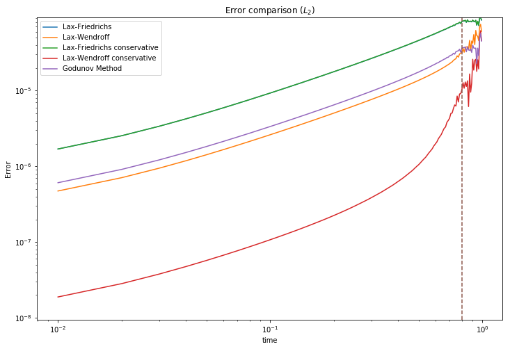

```python
compare(L2)
```

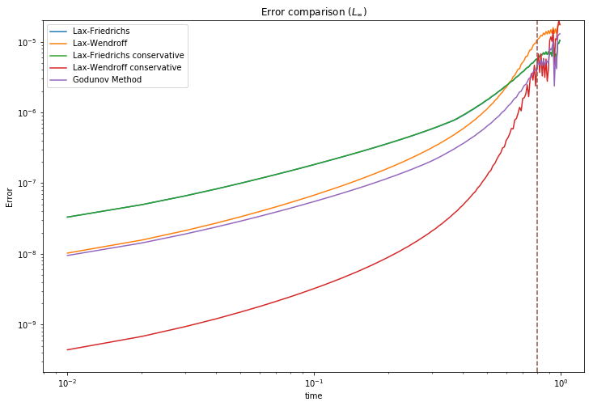

```python
compare(L_inf)
```

## References

*[1] Holmes, E. E., Lewis, M. A., Banks, J. E. and Veit, R. R. (1994), Partial Differential Equations in Ecology: Spatial Interactions and Population Dynamics. Ecology, 75: 17–29. doi:10.2307/1939378*

[2] May, R. M. (1976). Simple mathematical models with very complicated dynamics. Nature, 261, 459. Retrieved from http://dx.doi.org/10.1038/261459a0

[3] Godunov, S. K. (n.d.). Finite Difference Method for Numerical Computation of Discontinuous Solutions of the Equations of Fluid Dynamics.

[4] Treiber, M., and Kesting, A. (2013). Traffic Flow Dynamics. Traffic Flow Dynamics. http://doi.org/10.1007/978-3-642-32460-4

[5] Helbing, D. (2001). Traffic and related self-driven many-particle systems. Reviews of Modern Physics, 73(4), 1067–1141. http://doi.org/10.1103/RevModPhys.73.1067

[6] M.J.Lighthill, G.B.Whitham, On kinematic waves II: A theory of traffic flow on long, crowded roads. Proceedings of the Royal Society of London Series A 229, 317-345, 1955

[7] Laney, C. B. (1998). Computational gasdynamics. Cambridge university press.

[8] Godunov, S. K. (1959). A difference method for numerical calculation of discontinuous solutions of the equations of hydrodynamics. Matematicheskii Sbornik, 89(3), 271-306.

[9] Toro, E. F. (2013). Riemann solvers and numerical methods for fluid dynamics: a practical introduction. Springer Science and Business Media.